# A3: Incarceration

Laila Gmerek

### Introduction

In the United States, the issue of incarceration presents a complex and pressing challenge. With America having the highest number of people incarcerated in the world, this phenomenon disproportionately affects people of color, especially Black individuals, due to historical and present-day racism. The consequences of these disparities are far-reaching, necessitating a deeper analysis of the trends and factors contributing to the unequal distribution of incarceration rates.

This assignment focuses on using data analysis and visualization to uncover patterns of inequality within the prison and jail populations. The data is sourced from the Vera Institute, a reputable organization collecting information on incarceration trends. The datasets under consideration provide insights into prison population per county/state, jail population per county/state, and the rate of incarceration per 100,000 people.

The aim of this analysis is twofold: first, to understand the trajectory of prison and jail populations over time; second, to examine how race and gender intertwine with these trends. By conducting this investigation, we hope to identify potential solutions and shed light on areas that require greater attention from the public and policymakers.

As the sole researcher on this project, I have carefully chosen specific variables to analyze, considering their relevance in illuminating the complex dynamics of incarceration in America. Through this exploration, I seek to contribute to a broader understanding of the challenges faced by impacted communities and advocate for social justice and equity.

### Summary Information

In this analysis, my focus revolves around pivotal variables linked to the prison population per county/state. Specifically, I’ve delved into the following variables:

The `mean_total_pop` showcases an average of approximately *84,300.51*, offering insights into the typical representation of the incarcerated population across different regions. Contrasting this, the `max_total_pop` value stands out, reaching an impressive *10,120,540*. This underlines areas grappling with the highest prison populations. On the other end of the spectrum, the `min_total_pop` value, set at *0*, hints at regions with lower incarceration rates or potentially no incarcerated individuals.

The `sd_total_pop` or standard deviation of `total_population` at *303,312.1* reveals considerable variability in incarceration rates across various regions. The `median_total_pop` was *22970*.

In summary, these insights illuminate substantial diversity within the prison population across counties/states. Certain regions experience notably higher incarceration rates than others. The wide range of values underscores the need for a holistic, nuanced approach to address incarceration and criminal justice issues. Armed with these summary statistics, we’re poised for further exploration and policy development to foster an equitable and effective criminal justice system.

### The Dataset

#### Data Collection

The data for this assignment was collected by the Vera Institute of Justice. They have compiled county- and jurisdiction-level jail data from 1970 to 2018 and prison data from 1983 to 2016. Additionally, state-level prison data for the years 2019 to 2021 is also included in the dataset.

#### Data Collection Method

The data was collected through various sources and data collections, including the Census of Jails (COJ) and the Annual Survey of Jails (ASJ), conducted by the Bureau of Justice Statistics (BJS). The COJ covers all jails and is conducted every five to eight years since 1970, while the ASJ covers about one-third of jails, including most of the largest jails, and is conducted in non-census years since 1982. The National Corrections Reporting Program (NCRP) data collection is also used for county-level data.

#### Purpose of Data Collection

The data was collected to provide a comprehensive understanding of incarceration trends in the United States. By examining jail and prison incarceration data at the county and jurisdiction levels, the Vera Institute seeks to analyze the causes and consequences of high incarceration rates. The ultimate goal is to inform the public dialogue, advance research, and guide changes to justice policy and practice, particularly concerning mass incarceration and its impact on communities.

#### Columns

There are 36 columns in the data set

#### Rows

There are 153,811 rows

#### Ethical Considersations

When working with incarceration data, ethical considerations related to privacy and consent are important. The data likely contains sensitive information about individuals who have been incarcerated. Therefore, researchers must ensure that the data is appropriately anonymized and aggregated to protect the identities of those individuals. Additionally, any analysis that involves demographic characteristics, such as race and gender, should be approached with sensitivity and an understanding of the potential implications of the findings.

### Limitations and Problems

One possible limitation of the data is that it may not cover more recent years for some variables, as the latest state-level prison data is available up to the year 2021. Researchers should be mindful of potential data gaps and consider how they might impact the analysis.

Another limitation may be the potential underrepresentation of smaller jails or jurisdictions, as the data relies on the Annual Survey of Jails, which covers about one-third of jails. This could introduce sampling biases that need to be taken into account during analysis.

Furthermore, while the dataset provides valuable insights into incarceration trends, it may not capture all factors influencing incarceration rates comprehensively. Additional contextual factors, such as socioeconomic status, drug policies, and other systemic issues, could play a role in the observed trends and would require careful consideration in the analysis.

Researchers should also be aware of any potential biases in the data collection process, such as reporting discrepancies or changes in data collection methodologies over time, which could impact the accuracy and reliability of the findings.

In summary, while the dataset provided by the Vera Institute offers valuable information on incarceration trends, researchers must approach its analysis with awareness of its limitations and potential ethical implications.

### Trends Over Time Chart

#### Black to White Inmate Population Ratio in US from 1990 to present

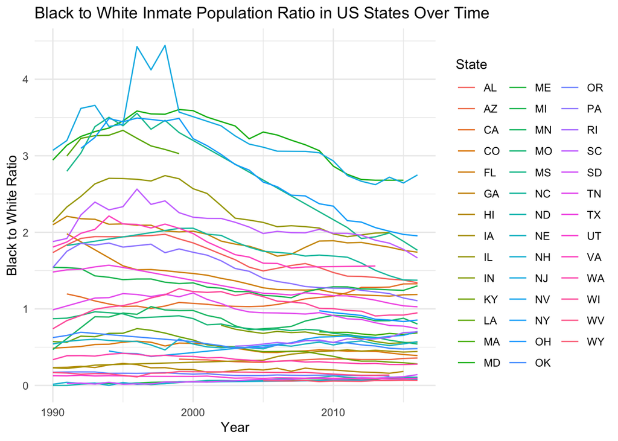

The Trends Over Time Chart portrays the evolving dynamics of the black-to-white inmate population ratio in U.S. states starting from 1990. The chart highlights the shifts in these ratios over the years, showcasing variations among states and offering a comprehensive view of the racial disparities within the criminal justice system. This visualization serves as a valuable tool for analyzing the progress and challenges related to racial equity and incarceration, prompting thoughtful considerations for policy reforms and further research in this critical domain. The insights derived from this analysis contribute to a deeper comprehension of the complexities surrounding racial disparities in incarceration rates, fostering informed discussions on matters of social justice and fairness.

### Variable Comparison Chart

#### Black Prison Population in King County, WA (1990-2018)

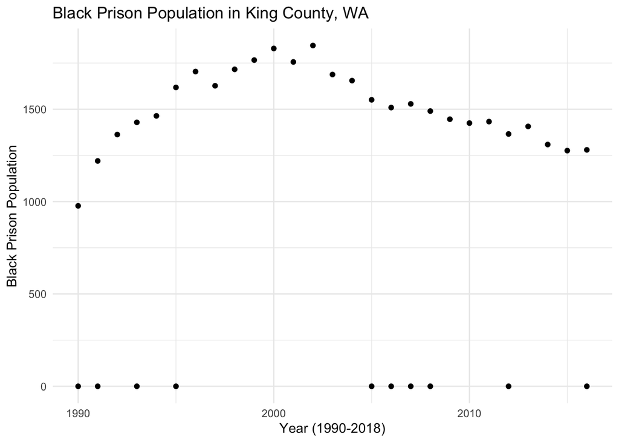

The Variable Comparison Chart highlights the trajectory of the black prison population within King County, Washington, from 1990 to 2018. Depicted as a scatter plot, each data point corresponds to a specific year, allowing us to observe shifts and trends over time. The x-axis represents the years, while the y-axis indicates the ‘Black Prison Population.’ The chart enables the identification of patterns, fluctuations, and potential correlations in the incarceration rates of black individuals within the county. Notably, this visualization provides insights into the local dynamics of the criminal justice system and underscores the importance of examining demographic-specific trends. By observing the chart, we can gain a deeper understanding of the changes in the black prison population over this time period and its implications for criminal justice policies and societal discussions.

### Map

#### Prison Population Map

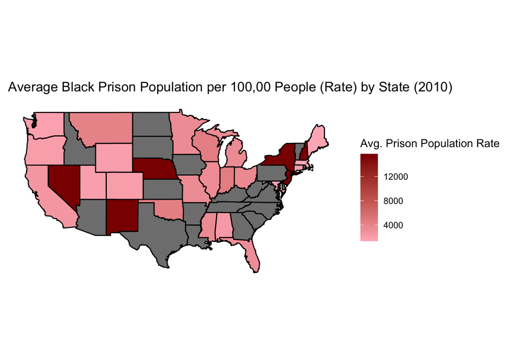

The Prison Population Map provides a visual representation of the distribution of incarcerated individuals across the United States, drawing on data sourced from the Vera Institute of Justice. By integrating this map into the analysis, its purpose is to visually uncover patterns and disparities in incarceration rates, thereby illuminating the intricate dynamics within the criminal justice system. The map accentuates clusters of prison populations in various regions, indicating potential divergences in state-level policies and practices. Additionally, it brings attention to the disparities evident between states, underscoring the necessity for equitable justice reforms.